# Influence of Time Since HIV Diagnosis on Seeking Health Information Online

Adam Northrup

March 19, 2019

## Abstract

This analysis will determine whether time since HIV diagnosis plays a role in whether an HIV-positive youth seeks health information online. Data constitutes responses from surveys administered to patients at 10 clinical sites across the country. The effect of time since diagnosis will be evaluated when controlling for age, race, gender, sexual orientation, education, and employment status. The event of interest, `HealthInfo`, is a binary event, and can be characterized by the probability of the event ($\pi$). The effect of time will be estimated using logistic regression, and will take the form of an odds ratio, $e^{\alpha}$. $\alpha$ is a vector of regression coefficients. Regression coefficients are expected to follow different normal distributions, with expectations taken from prior research. Survey results from each site may be correlated, and so a site-specific effect will be considered.

## Introduction

Investigators are interested in health-information seeking behavior in order to better adapt interventions geared toward HIV positive youth. The purpose of the survey is ultimately to determine factors that encourage participants to take an active role in their health care. This analysis will determine if one such factor, time since HIV diagnosis, has an effect on health-seeking behavior.

## Methods

### Data

Data comes from the Health Resources and Services Administration’s Special Projects of National Significance Initiative: Use of Social Media to Improve Engagement, Retention, and Health Outcomes along the HIV Care Continuum. Participant and site identifying information have been removed. Participants were HIV positive youth and young adults (ages 16-34), and data were self-reported by participants between 2016 and 2018. Sites are located in major cities, distributed across the United States. Participants at sites have different demographic makeup, and while these demographics will be controlled for, it is thought that there may be correlation for outcomes among participants within site. Data consist of a baseline survey taken upon entrance into the study, and a 6-month follow-up.

`HealthInfo` is a binary variable, indicating whether a participant has reported looking for health-related information online. There are multiple types of health information that participants may report searching for, including cold/flu symptoms, transgender therapies, and STD information. If participants responded affirmatively to any of these, `HealthInfo` is recorded as a 1, otherwise a 0. Since these questions are asked in the 6-month follow-up, participants that were lost to follow-up are not included in this analysis. Ideally, $\chi^2$ testing would be performed between those participants included and those lost to follow-up, but those lost to follow-up were not included in the data set.

Demographic information was taken from the baseline survey. Some participants were given only a 6-month survey and no baseline survey, thus they were not included in the data set.

Of the available covariates, only `SINCEHIV` (time since HIV diagnosis), and `Age` are continuous. Figure 1 shows the distribution for `Age` broken down by whether participants sought health information. Figure 2 shows the distribution for `SINCEHIV` and the log of `SINCEHIV`.

Variables for gender, sexual orientation, ethnicity, race, and education are coded as binary variables with numerous options that were pared down for the purposes of this analysis. Employment status was not already coded as binary, and so had to be treated differently, as detailed below. Demographic covariates were collapsed to reflect categories for which prior information was available.

Gender was reduced to male, female, and ‘other’ categories. Cis and trans men were collapsed together, and the same for women. A new variable, `LGBTQ` was created from gender and sexual orientation, indicating whether participant is LGBTQ or non-LGBTQ.

Participants who indicated Latino were marked as Latino, and the rest were broken into different race categories. Categories were created for black non-Latinos, white non-Latinos, and others.

Education was reduced to high school or high school equivalent or less, and more than a high school education.

The employment status question of the survey allowed participants to check all that apply, including: student, full-time or part-time employed, on disability, unemployed and looking for work, or unemployed and not looking. In order to code employment in dummy variables, these were collapsed into fewer categories and the different combinations were evaluated, with the most infrequent collapsed into an ‘other’ category. The remaining categories include student, employed, disabled, and unemployed. Student includes employed and unemployed students. Other combinations were rare.

Demographic information of participants is summarized in Table 1. There are 686 participants included in the analysis, of which 627 are LGBTQ, 498 are men, 167 women, 197 are Latino, 329 are black (not Latino), and 116 are white (not Latino). Approximately half had more than high school educations, 294 are employed, and 254 are unemployed. The number from each group who sought out health information online is also documented in Table 1.

### Models

Four models were evaluated and compared to determine the effect of `SINCEHIV`. The first model included `Age`, but since `Age` was found to be correlated with `SINCEHIV`, ($\rho$ = 0.46, Figure 1), a second model without `Age` was considered. Both of these models included `Site` as a random effect, as participant outcomes were anticipated to be correlated within site. The third model did not include random effects, and would include `Age` if the first model is shown to outperform the second model without `Age`. The fourth model excluddes `Age`, and includes random effects, but used the log of `SINCEHIV`. Models followed the general form:
$$Y_i \sim Bernoulli(\pi_i) \\
log \frac{\pi_i}{1 - \pi_i} = x_i^T\alpha + \beta_{j}$$
with the following distributions:
$$\beta_j \sim Norm_o(0, \tau_b) \\
\tau_b \sim Gamma(0.25, 0.25) \\
\alpha_k \sim Norm(\mu_k, 1)$$

Regression coefficients were expected to follow normal distributions, though these distributions are unknown. They were estimated to be negative, zero, or positive, with means of -1, 0, or 1, respectively, with standard deviation of 1. This allows each distribution to include zero. Prior information was taken from Rideout and Fox, 2018, which assessed the effects of age, gender, LGBTQ status, and race on health-seeking behavior of teens and young adults. Effects of education and employment status were not detailed, priors for these were based on intuition instead. See Table 2 for prior normal distribution parameters. `SINCEHIV` was expected to have a negative effect, since newly diagnosed participants were thought likely to attempt to learn about their diagnosis. Rideout and Fox reported higher likelihood of seeking health information with increased age, and for women and LGBTQ over men and non-LGBTQ. Race was reported as having no effect. It was estimated that participants with higher education and employment would have increased likelihood of seeking health information.

The model that best converged and had the lowest DIC was selected. Initial iterations were set to 1100 with 100 burnin and thinning of 1. Convergence was assessed and sensitivity analysis performed for Models 1 and 2 prior to evaluation of later models. Sensitivity analysis included increasing iterations and thinning. Poor convergence may have also necessitated changing precision levels for random effects. Once a model was selected, linearity was assessed and any necessary transformations made (e.g. log of `SINCEHIV`). The effects of `SINCEHIV` were then determined.

## Results

The regression coefficient ($\alpha_2$) for time since diagnosis (`SINCEHIV`) on whether a participant sought health information online is seen in Table 4 as -0.40. Table 4 also includes the coefficients for other covariates, but the effects of these covariates were not of interest in the research question. The estimate for the SD for the random effect distribution, $\tau_b$, is also listed.

## Conclusions

Table 4 shows that the 2.5th percentile and 97.5th percentile for $\alpha_2$ are both below zero, indicating that there is indeed an effect on health-seeking behavior. This is reinforced by the fact that all estimates of $\alpha_2$ are below zero, and thus the probability of the $\alpha_2$ being below zero is approximately 1.00. This indicates that for each increase in year since HIV diagnosis, the odds of seeking health information online is reduced by 0.33. Figure 7 shows the prior, likelihood, and posterior distributions, together and separated due to the extreme differences in scale.

## References

Rideout, Victoria, and Susannah Fox. “Digital Health Practices, Social Media Use, and Mental Well-Being Among Teens and Young Adults in the U.S.” *Digital Health Practices, Social Media Use, and Mental Well-Being Among Teens and Young Adults in the U.S.*, Well Being Trust, wellbeingtrust.org/areas-of-focus/policy-and-advocacy/reports/digital-health-practices/.

## Appendix

### Model Printouts

#### Model 1

This model includes 13 covariates including `Age`, with regression coefficients (alpha), and random effects (beta).

```r
cat(
"model{
  for (i in 1:N.obs) {
        y[i] ~ dbern(pie[i])
    logit(pie[i]) <- inprod(x[i, ], alpha[]) + beta[site[i]]
  }
  for (j in 1:N.sites) {
    beta[j] ~ dnorm(0, tau)
  }
  alpha[1] ~ dnorm(mu[1], tau.a)
  alpha[2] ~ dnorm(mu[2], tau.a)
  alpha[3] ~ dnorm(mu[3], tau.a)
  alpha[4] ~ dnorm(mu[4], tau.a)
  alpha[5] ~ dnorm(mu[5], tau.a)
  alpha[6] ~ dnorm(mu[6], tau.a)
  alpha[7] ~ dnorm(mu[7], tau.a)
  alpha[8] ~ dnorm(mu[8], tau.a)
  alpha[9] ~ dnorm(mu[9], tau.a)
  alpha[10] ~ dnorm(mu[10], tau.a)
  alpha[11] ~ dnorm(mu[11], tau.a)
  alpha[12] ~ dnorm(mu[12], tau.a)
  alpha[13] ~ dnorm(mu[13], tau.a)
  tau ~ dgamma(b1, b2)
  sigma <- 1/ tau
}",
  fill = TRUE,
    file = "model1_logit_mixed.txt")
```

#### Model 2

This model does not include `Age`, indicated by 12 regression coefficients (alpha). This model includes random effects for `Site` (beta).

```r
cat(
"model{
  for (i in 1:N.obs) {
        y[i] ~ dbern(pie[i])
    logit(pie[i]) <- inprod(x[i, ], alpha[]) + beta[site[i]]
  }
  for (j in 1:N.sites) {
    beta[j] ~ dnorm(0, tau)
  }
  alpha[1] ~ dnorm(mu[1], tau.a)
  alpha[2] ~ dnorm(mu[2], tau.a)
  alpha[3] ~ dnorm(mu[3], tau.a)
  alpha[4] ~ dnorm(mu[4], tau.a)
  alpha[5] ~ dnorm(mu[5], tau.a)
  alpha[6] ~ dnorm(mu[6], tau.a)
  alpha[7] ~ dnorm(mu[7], tau.a)
  alpha[8] ~ dnorm(mu[8], tau.a)
  alpha[9] ~ dnorm(mu[9], tau.a)
  alpha[10] ~ dnorm(mu[10], tau.a)
  alpha[11] ~ dnorm(mu[11], tau.a)
  alpha[12] ~ dnorm(mu[12], tau.a)
  tau ~ dgamma(b1, b2)
  sigma <- 1/ tau
}",
  fill = TRUE,
    file = "model2_logit_mixed.txt")
```

#### Model 3

This model does not include `Age` (see only 12 alphas) or random effects.

```r
cat(
"model{
  for (i in 1:N.obs) {
        y[i] ~ dbern(pie[i])
    logit(pie[i]) <- inprod(x[i, ], alpha[])
  }
  alpha[1] ~ dnorm(mu[1], tau.a)
  alpha[2] ~ dnorm(mu[2], tau.a)
  alpha[3] ~ dnorm(mu[3], tau.a)
  alpha[4] ~ dnorm(mu[4], tau.a)
  alpha[5] ~ dnorm(mu[5], tau.a)
  alpha[6] ~ dnorm(mu[6], tau.a)
  alpha[7] ~ dnorm(mu[7], tau.a)
  alpha[8] ~ dnorm(mu[8], tau.a)
  alpha[9] ~ dnorm(mu[9], tau.a)
  alpha[10] ~ dnorm(mu[10], tau.a)
  alpha[11] ~ dnorm(mu[11], tau.a)
  alpha[12] ~ dnorm(mu[12], tau.a)
  tau ~ dgamma(b1, b2)
  sigma <- 1/ tau
}",
  fill = TRUE,
    file = "model3_logit_fixed.txt")
```

### Sample Summary

Table 1. Participant Characteristics

| Variable | Sample Frequency | Seeking Health Info |
| --- | --- | --- |
| Number of participants | 686 | NA |
| **Continuous Variables, Mean (SD)** |  |  |
| Age | 27.1 (4.2) | NA |
| Time since HIV diagnosis | 6 (4.3) | NA |
| **LGBTQ Status, Number (%) of Participants** |  |  |
| LGBTQ | 627 (91.4%) | 341 (54.4%) |
| Non-LGBTQ | 59 (8.6%) | 21 (35.6%) |
| **Gender, Number (%) of Participants** |  |  |
| Man | 498 (72.6%) | 301 (60.4%) |
| Woman | 167 (24.3%) | 50 (29.9%) |
| Other gender | 21 (3.1%) | 11 (52.4%) |
| **Ethnicity and Race, Number (%) of Participants** |  |  |
| Latino | 197 (28.7%) | 87 (44.2%) |
| Black, Not Latino | 329 (48.0%) | 170 (51.7%) |
| White, Not Latino | 116 (16.9%) | 79 (68.1%) |
| Other race | 44 (6.4%) | 26 (59.1%) |
| **Education, Number (%) of Participants** |  |  |
| High school, equivalent or less | 355 (51.7%) | 141 (39.7%) |
| More than high school | 331 (48.3%) | 221 (66.8%) |
| **Employment Status, Number (%) of Participants** |  |  |
| Employed | 294 (42.9%) | 172 (58.5%) |
| Unemployed | 254 (37.0%) | 123 (48.4%) |
| Student | 57 (8.3%) | 34 (59.6%) |
| Disabled | 54 (7.9%) | 19 (35.2%) |
| Other | 27 (3.9%) | 14 (51.9%) |

### Prior Distributions

Table 2. Prior Normal Parameters

| Parameter | alpha | Mean | SD |
| --- | --- | --- | --- |
| Intercept | alpha[1] | 0 | 1 |
| SINCEHIV | alpha[2] | -1 | 1 |
| Age | alpha[3] | 1 | 1 |
| Gender_Woman | alpha[4] | 1 | 1 |
| Gender_Other | alpha[5] | 1 | 1 |
| Ed_Higher | alpha[6] | 1 | 1 |
| Race_Black | alpha[7] | 0 | 1 |
| Race_White | alpha[8] | 0 | 1 |
| Race_Other | alpha[9] | 0 | 1 |
| Employ_Student | alpha[10] | 1 | 1 |
| Employ_Employed | alpha[11] | 1 | 1 |
| Employ_Disabled | alpha[12] | 1 | 1 |
| Employ_Other | alpha[13] | 0 | 1 |

### Continuous Variable Distributions

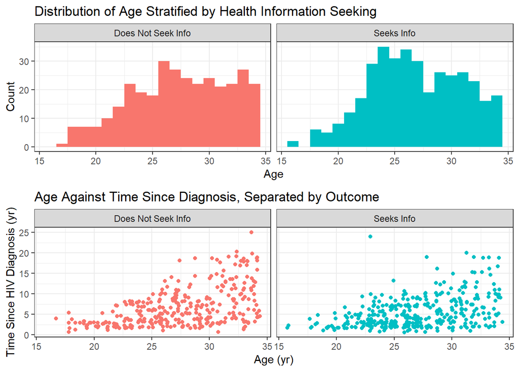

Figure 1. Distribution of Participant Age, Age against SINCEHIV

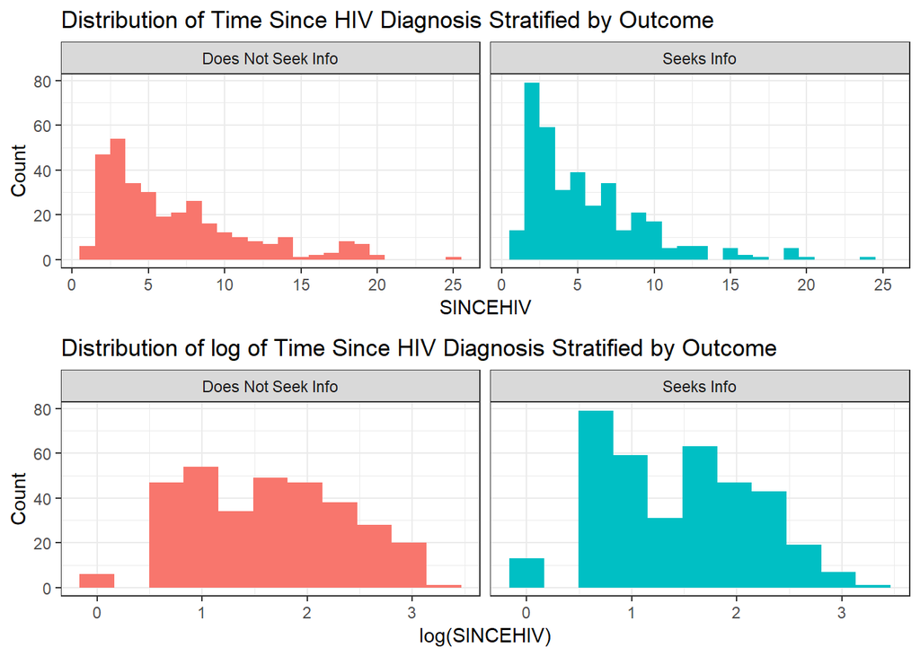

Figure 2. Distribution of SINCEHIV and log(SINCEHIV)

### Model Comparisons

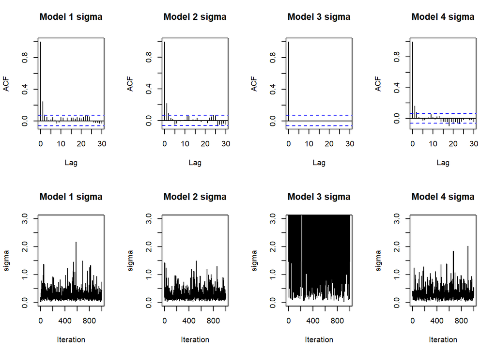

Figure 3. Autocorrelation and Convergence of Sigmas

Table 3. Model DIC

| Model | DIC |
| --- | --- |
| Model 1 | 866.1 |
| Model 2 | 865.0 |
| Model 3 | 873.5 |
| Model 4 | 861.9 |

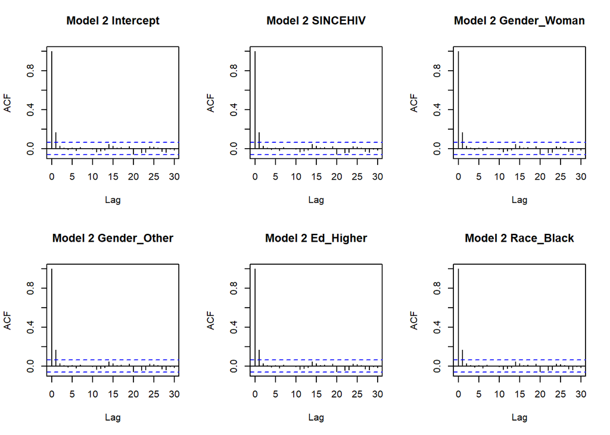

Figure 4. Autocorrelation and Convergence of Model 2 Alphas 1-6

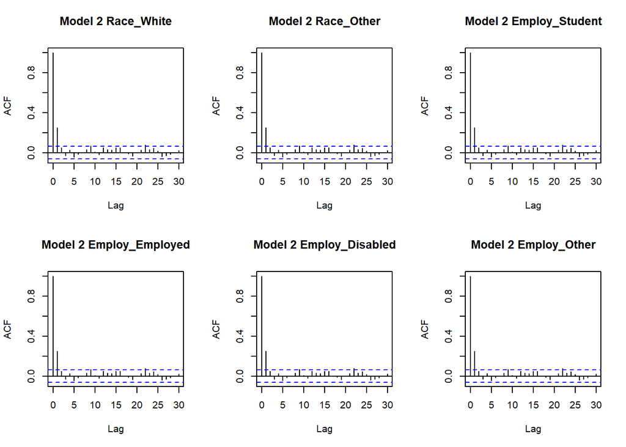

[figure not shown]

[figure not shown]

Figure 5. Autocorrelation and Convergence of Model 2 Alphas 7-12

### Model Diagnostics

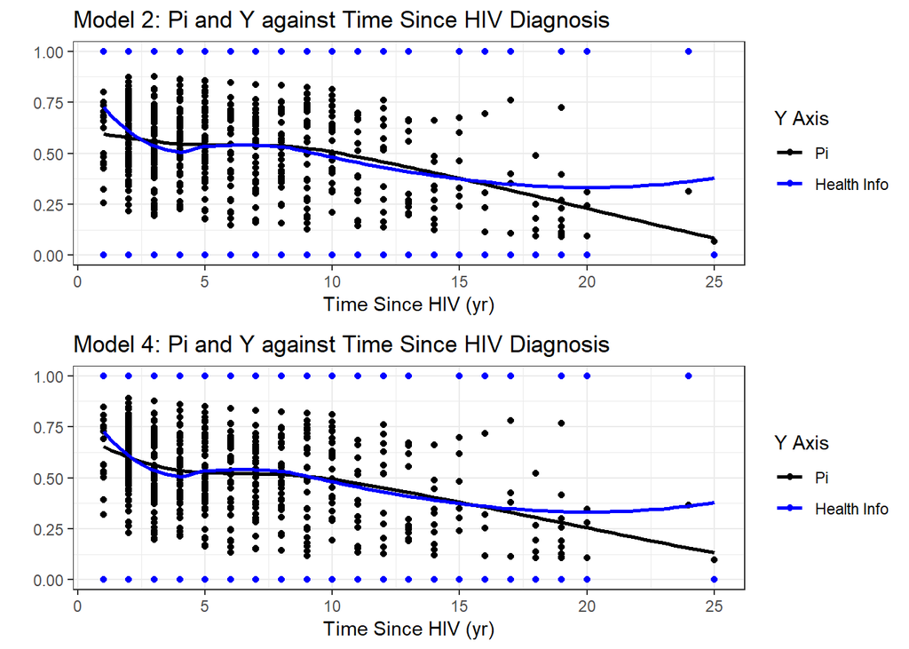

Figure 6. Model Diagnostics

### Results

Table 4. Model Estimates

| Covariate | Parameter | Mean | SD | 2.5% | 97.5% | P>0 | P<0 |
| --- | --- | --- | --- | --- | --- | --- | --- |
| Intercept | alpha[1] | 0.17 | 0.32 | -0.45 | 0.80 | 0.71 | 0.29 |
| SINCEHIV | alpha[2] | -0.40 | 0.13 | -0.65 | -0.15 | 0.00 | 1.00 |
| Gender_Woman | alpha[3] | -0.46 | 0.26 | -0.96 | 0.05 | 0.04 | 0.96 |
| Gender_Other | alpha[4] | 0.16 | 0.45 | -0.71 | 1.05 | 0.64 | 0.36 |
| Ed_Higher | alpha[5] | 0.86 | 0.17 | 0.52 | 1.20 | 1.00 | 0.00 |
| Race_Black | alpha[6] | 0.18 | 0.22 | -0.24 | 0.60 | 0.79 | 0.21 |
| Race_White | alpha[7] | 0.65 | 0.27 | 0.13 | 1.18 | 0.99 | 0.01 |
| Race_Other | alpha[8] | 0.17 | 0.36 | -0.54 | 0.89 | 0.68 | 0.32 |
| Employ_Student | alpha[9] | 0.27 | 0.31 | -0.35 | 0.90 | 0.81 | 0.19 |
| Employ_Employed | alpha[10] | 0.22 | 0.19 | -0.15 | 0.59 | 0.88 | 0.12 |
| Employ_Disabled | alpha[11] | -0.24 | 0.33 | -0.90 | 0.40 | 0.23 | 0.77 |
| Employ_Other | alpha[12] | -0.10 | 0.41 | -0.89 | 0.70 | 0.40 | 0.60 |
| Site | sigma | 0.31 | 0.22 | 0.09 | 0.86 | 1.00 | 0.00 |

### SINCEHIV Coefficient Distributions

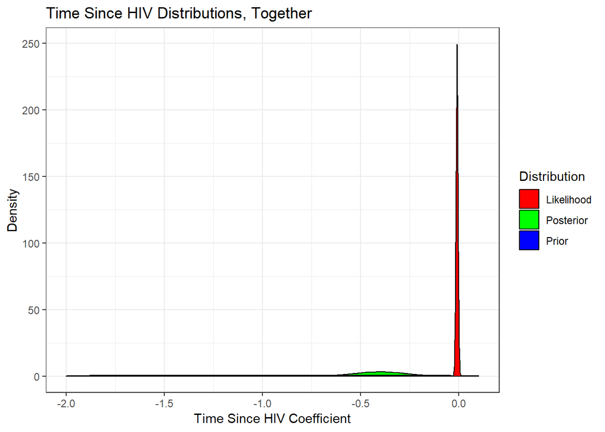

Figure 7. SINCEHIV Distributions

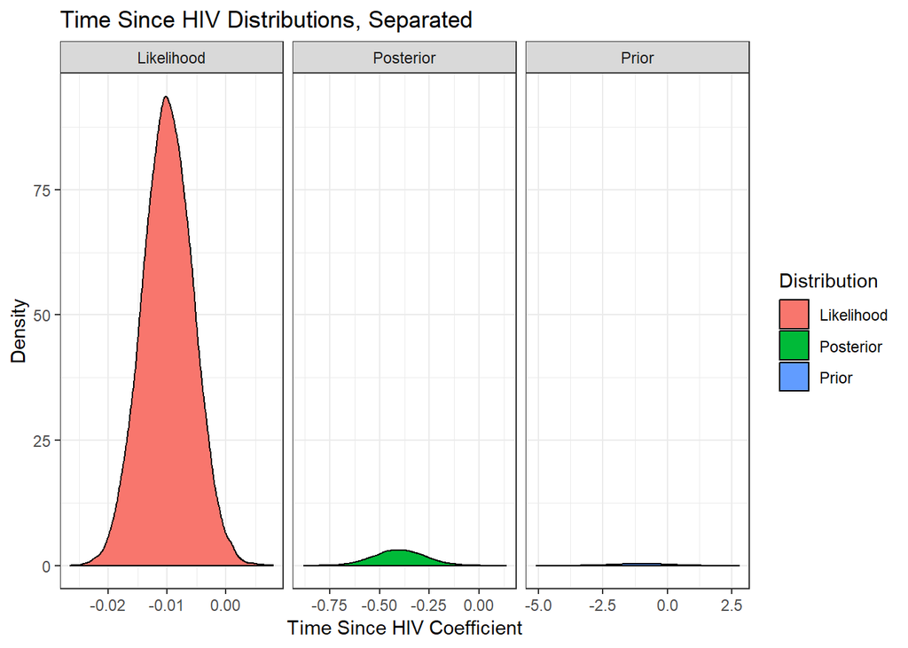

Figure 7. SINCEHIV Distributions